# Opportunity Window Report

2024-11-11

## Diagnostic Opportunity Window Report

This report summarizes the results of the bootstrapping change-point approach to select the diagnostic opportunity window. For this report we analyzed opportunity windows ranging from 10 to 100 days prior to the index diagnosis.

The following figure depicts the number of patients with any visit or an SSD-related visit each day prior to diagnosis:

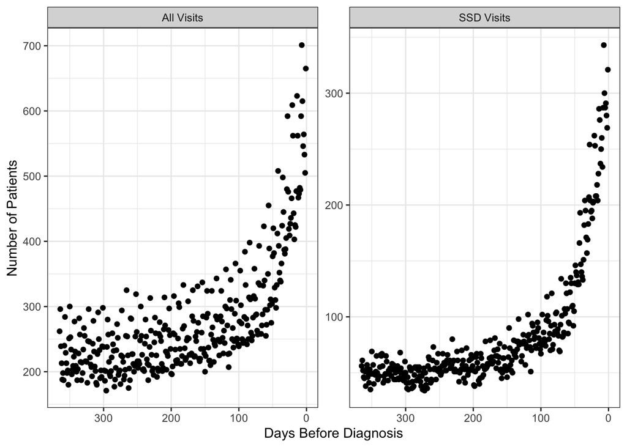

## SSD Visits

This section summarizes results using counts of SSD-related visits.

The following figure depicts the in-sample and out-of-sample performance of various bounds on the opportunity window and different trends.

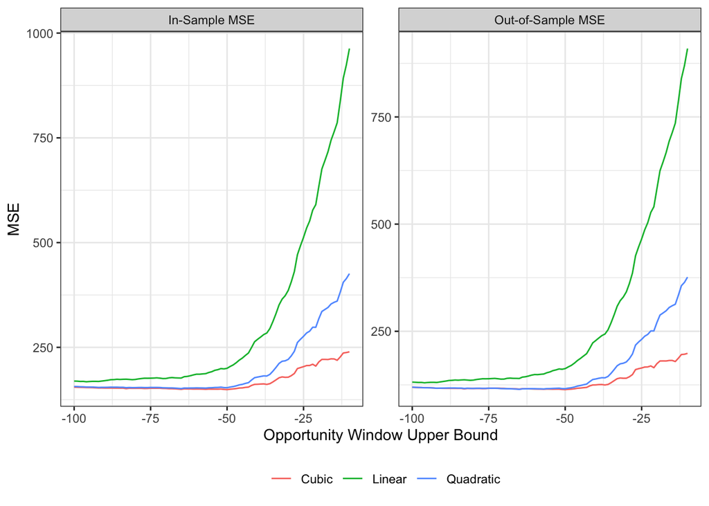

The following table depicts the top 10 specifications based on out-of-sample performance

| Bound (Days) | Model | MSE |
| --- | --- | --- |
| 50 | Cubic | 114.0096 |
| 51 | Cubic | 114.4004 |
| 65 | Quadratic | 114.6753 |
| 49 | Cubic | 114.6951 |
| 57 | Cubic | 114.8966 |
| 54 | Cubic | 114.9666 |
| 53 | Cubic | 115.0701 |
| 52 | Cubic | 115.0862 |
| 48 | Cubic | 115.0882 |
| 65 | Cubic | 115.1349 |

The following figure depicts the observed and expected trend for the top 4 models based on out-of-sample performance:

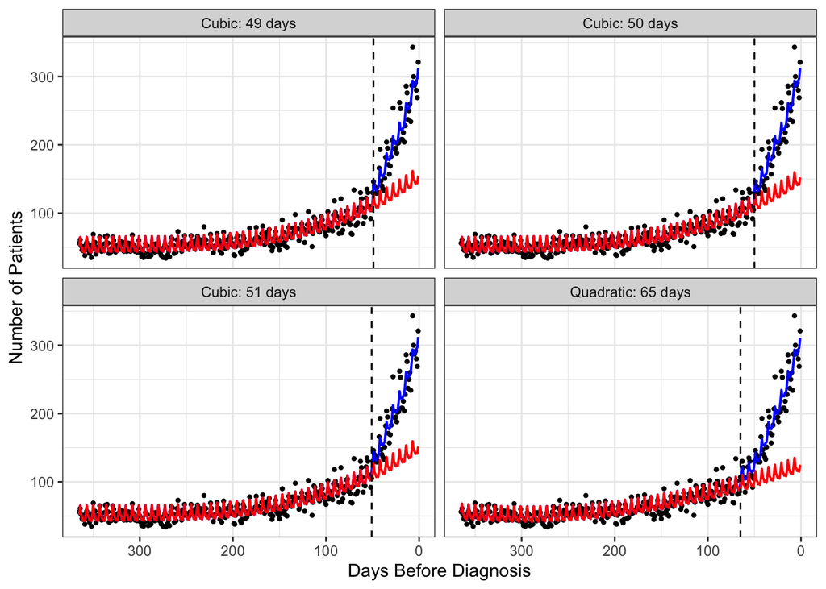

The following table depicts the 10 best models for each trend.

| Rank | Linear Bound | Linear MSE | Quadratic Bound | Quadratic MSE | Cubic Bound | Cubic MSE |
| --- | --- | --- | --- | --- | --- | --- |
| 1 | 96 | 129.86 | 65 | 114.68 | 50 | 114.01 |
| 2 | 95 | 130.51 | 66 | 115.28 | 51 | 114.40 |
| 3 | 92 | 130.63 | 57 | 115.44 | 49 | 114.70 |
| 4 | 98 | 130.64 | 67 | 115.56 | 57 | 114.90 |
| 5 | 97 | 130.73 | 58 | 115.68 | 54 | 114.97 |
| 6 | 94 | 130.95 | 59 | 115.75 | 53 | 115.07 |
| 7 | 93 | 130.98 | 64 | 115.77 | 52 | 115.09 |
| 8 | 99 | 131.12 | 63 | 115.86 | 48 | 115.09 |
| 9 | 100 | 131.50 | 68 | 115.97 | 65 | 115.13 |
| 10 | 91 | 131.72 | 62 | 115.99 | 55 | 115.14 |

### Linear Models

The following figure depicts the top 4 performing linear models based on out-of-sample MSE

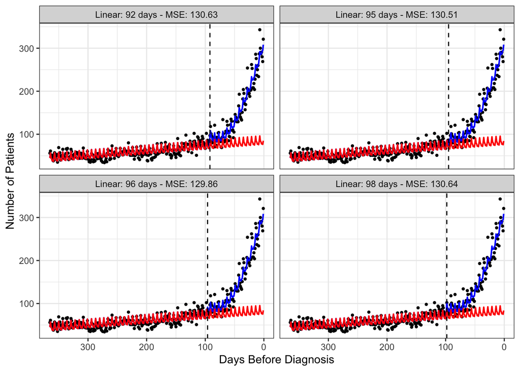

## All Visits

This section summarizes results using counts of all visits.

The following figure depicts the in-sample and out-of-sample performance of various bounds on the opportunity window and different trends.

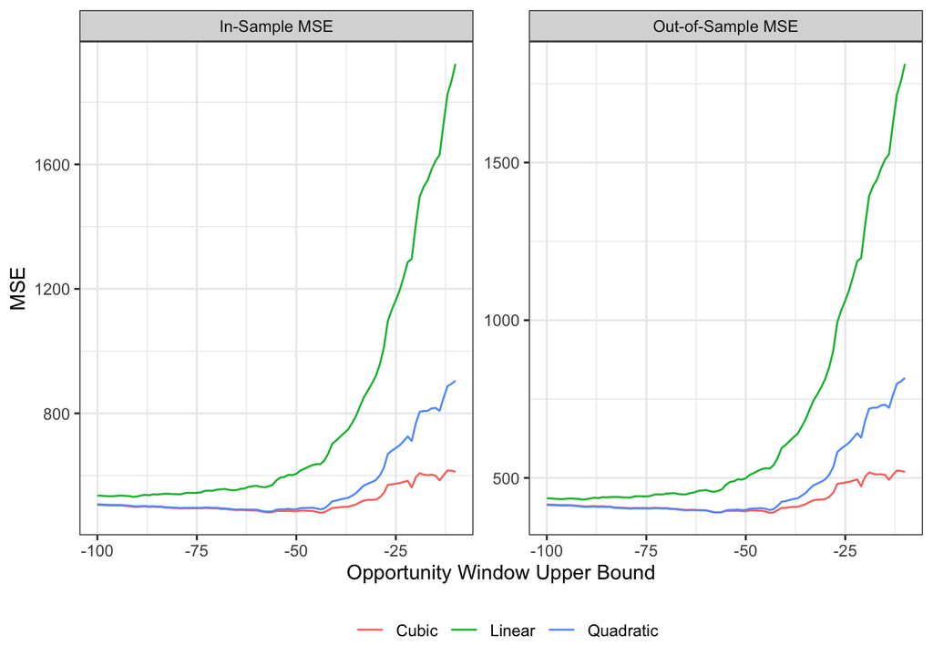

The following table depicts the top 10 specifications based on out-of-sample performance

| Bound (Days) | Model | MSE |
| --- | --- | --- |
| 44 | Cubic | 389.4897 |
| 57 | Quadratic | 390.4319 |
| 43 | Cubic | 390.6607 |
| 57 | Cubic | 390.7257 |
| 58 | Quadratic | 390.8073 |
| 58 | Cubic | 391.3843 |
| 56 | Cubic | 391.5119 |
| 56 | Quadratic | 391.5847 |
| 45 | Cubic | 393.3713 |
| 59 | Quadratic | 393.9160 |

The following figure depicts the observed and expected trend for the top 4 models based on out-of-sample performance:

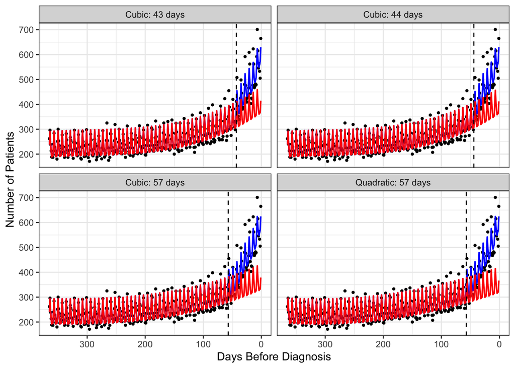

The following table depicts the 10 best models for each trend.

| Rank | Linear Bound | Linear MSE | Quadratic Bound | Quadratic MSE | Cubic Bound | Cubic MSE |
| --- | --- | --- | --- | --- | --- | --- |
| 1 | 91 | 431.11 | 57 | 390.43 | 44 | 389.49 |
| 2 | 90 | 432.59 | 58 | 390.81 | 43 | 390.66 |
| 3 | 96 | 432.86 | 56 | 391.58 | 57 | 390.73 |
| 4 | 97 | 433.02 | 59 | 393.92 | 58 | 391.38 |
| 5 | 92 | 433.51 | 55 | 396.89 | 56 | 391.51 |
| 6 | 98 | 433.76 | 60 | 396.89 | 45 | 393.37 |
| 7 | 93 | 434.01 | 61 | 397.12 | 59 | 394.46 |
| 8 | 95 | 434.09 | 65 | 397.18 | 50 | 394.48 |
| 9 | 94 | 434.83 | 62 | 397.70 | 51 | 394.58 |
| 10 | 99 | 435.11 | 63 | 397.89 | 55 | 395.31 |

### Linear Models

The following figure depicts the top 4 performing linear models based on out-of-sample MSE

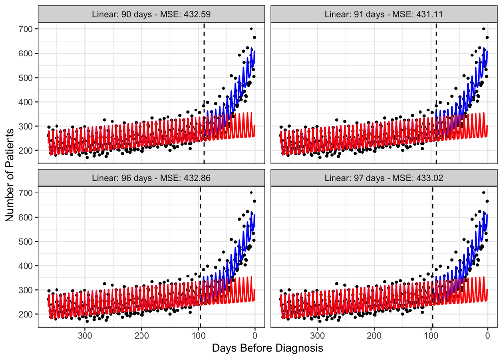

### Quadratic Models

The following figure depicts the top 4 performing quadratic models based on out-of-sample MSE

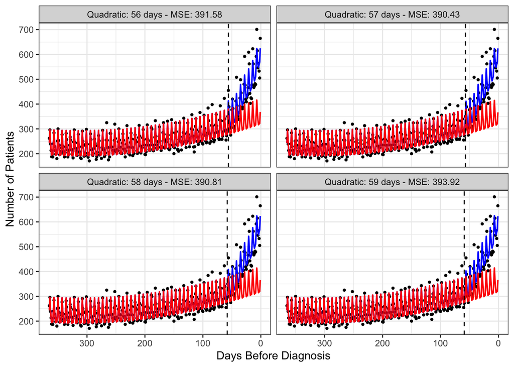

### Cubic Models

The following figure depicts the top 4 performing cubic models based on out-of-sample MSE

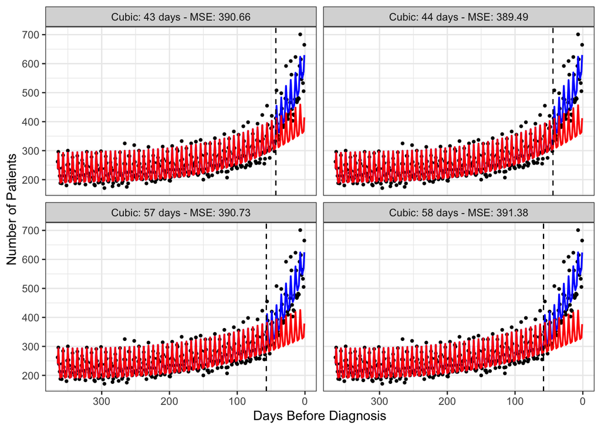